# **Project 2**, APS1070 Fall 2023

**Anomaly Detection Algorithm using Gaussian Mixture Model**

**Deadline: OCT 27, 11 PM**

**Academic Integrity**

This project is individual - it is to be completed on your own. If you have questions, please post your query in the APS1070 Piazza Q&A forums (the answer might be useful to others!).

Do not share your code with others, or post your work online. Do not submit code that you have not written yourself. Students suspected of plagiarism on a project, midterm or exam will be referred to the department for formal discipline for breaches of the Student Code of Conduct.

Please fill out the following:

- Name: Yi-Fan, Hung
- Student Number: 1010807799

### How to submit **(HTML + IPYNB)**

1. Download your notebook: `File -> Download .ipynb`
2. Click on the Files icon on the far left menu of Colab
3. Select & upload your `.ipynb` file you just downloaded, and then obtain its path (right click) (you might need to hit the Refresh button before your file shows up)
1. execute the following in a Colab cell:

   ```
   %%shell
   jupyter nbconvert --to html /PATH/TO/YOUR/NOTEBOOKFILE.ipynb
   ```

2. An HTML version of your notebook will appear in the files, so you can download it.
3. Submit **both** `HTML` and `IPYNB` files on Quercus for grading.

Ref: https://stackoverflow.com/a/64487858

## **Part 1: Getting started [1.5 Marks]**

We are going to work with a [credit card fraud detection](https://www.kaggle.com/datasets/mlg-ulb/creditcardfraud) dataset, consisting of transactions made by credit cards in September 2013 by European cardholders. The dataset contains only numerical input variables (`V1`, `V2`, … `V28`) which are the principal components obtained with PCA transformation (PCA will the introduced later in this course), due to confidentiality issues. The only features which have not been transformed with PCA are `Time` (seconds elapsed between each transaction and the first transaction in the dataset) and `Amount` (transaction Amount).\ This dataset contains 30 key features, which are not directly interpretable but contain meaningful information about the dataset. Load the dataset in CSV file using Pandas. The dataset is called `creditcard.csv`. Print out the first few columns of the dataset.

- How many rows are there? 284807 **[0.1]**
- Which column contains the targets? 31 **[0.1]**
- What is the meaning of target values? Fraud or not fraud (0 present normal --> non-fraud; 1 present abnormal --> fraud) **[0.2]**

```python
pip install wget
```

```
  Preparing metadata (setup.py) ... done
```

```python
import wget

wget.download('https://raw.githubusercontent.com/Sabaae/Dataset/master/creditcard.csv')
```

```
'creditcard.csv'
```

```python
import pandas as pd
import numpy as np
import matplotlib.pyplot as plt
import seaborn as sns
from sklearn.model_selection import train_test_split
from sklearn.preprocessing import StandardScaler
```

```python
file_path = 'creditcard.csv'
df = pd.read_csv(file_path)
print(df)
print('There are ' + str(df.shape[0]) + ' rows.')
print('There are ' + str(df.shape[1]) + ' columns.')
```

```
            Time         V1         V2        V3        V4        V5  \
0            0.0  -1.359807  -0.072781  2.536347  1.378155 -0.338321
1            0.0   1.191857   0.266151  0.166480  0.448154  0.060018
2            1.0  -1.358354  -1.340163  1.773209  0.379780 -0.503198
3            1.0  -0.966272  -0.185226  1.792993 -0.863291 -0.010309
4            2.0  -1.158233   0.877737  1.548718  0.403034 -0.407193
...          ...        ...        ...       ...       ...       ...
284802  172786.0 -11.881118  10.071785 -9.834783 -2.066656 -5.364473
284803  172787.0  -0.732789  -0.055080  2.035030 -0.738589  0.868229
284804  172788.0   1.919565  -0.301254 -3.249640 -0.557828  2.630515
284805  172788.0  -0.240440   0.530483  0.702510  0.689799 -0.377961
284806  172792.0  -0.533413  -0.189733  0.703337 -0.506271 -0.012546

              V6        V7        V8        V9  ...       V21       V22  \
0       0.462388  0.239599  0.098698  0.363787  ... -0.018307  0.277838
```

[output cut: 40 more lines]

It's important to know how many examples we have for each class when we work with a new dataset.

- What is the percentage of entries in the dataset for each class? **Non-fraud:99.8% / Fraud:0.2%** **[0.1]**
- Is this data considered balanced or unbalanced? Why is this the case? **Unbalanced. There is significantly more non-fraud data than fraud data. This is derived from a real-world scenario in which non-fraudulent transactions happen more frequently.** **[0.1]**
- Why is balance/imbalance important? How might this class ditribution affect a KNN classifier for example, which we explored in Project 1? **While it is unbalanced, it can lead to biased model outcome. For example while k gets larger, the result tends to return non-fraud transaction. It does have a high accuracy, however, it missing the fraud transaction is undesirable.** **[0.5]**
- What metrics should we use to evaluate a model in such cases? **Confusion matrix, F1 score or ROC would be a better performance matric.** **[0.2]**

```python
fraud_percentage = len(df[df['Class']==1]) / len(df[(df['Class']==1)|(df['Class']==0)])
print('Fraud percentage: ' + str(fraud_percentage))
nonfraud_percentage = len(df[df['Class']==0])/ len(df[(df['Class']==1)|(df['Class']==0)])
print('Non-fraud percentage: ' + str(nonfraud_percentage))
```

```
Fraud percentage: 0.001727485630620034
Non-fraud percentage: 0.9982725143693799
```

Next, split the dataset into a training (70%), validation (15%) and testing set (15%). Set the random state to 0. **[0.2]**

Make sure to separate out the column corresponding to the targets.

```python
### Split the data  ###
y = df['Class']
X = df.copy().drop(['Time', 'Amount', 'Class'], axis=1)
X_train, X_temp, y_train, y_temp = train_test_split(X, y, test_size=0.3, random_state=0)
X_val, X_test, y_val, y_test = train_test_split(X_temp, y_temp, test_size=0.5, random_state=0)
feature_name = df.columns.drop(['Time', 'Amount', 'Class'])
X_train = pd.DataFrame(X_train, columns=feature_name)
```

Now, let's take a look at the difference in distribution for all variables between non-fraudulent and fraudulent credit card transactions:

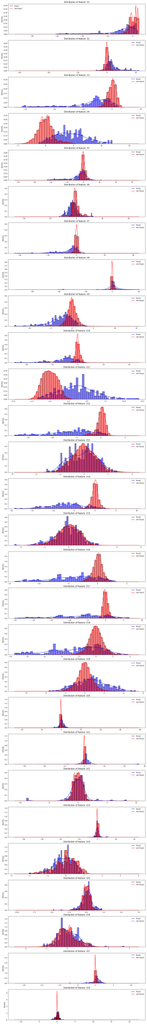

```python
import matplotlib.gridspec as gridspec
features=[f for f in df.columns if (not 'Class' in f) and (not 'Amount' in f) and (not 'Time' in f)]
nplots=np.size(features)
plt.figure(figsize=(15,4*nplots))
gs = gridspec.GridSpec(nplots,1)
for i, feat in enumerate(features):
    #print(feat)
    ax = plt.subplot(gs[i])
    sns.histplot(X_train[feat][y_train==1], stat="density", kde=True, color="blue", bins=50)
    sns.histplot(X_train[feat][y_train==0], stat="density", kde=True, color="red", bins=50)
    ax.legend(['fraud', 'not-fraud'],loc='best')
    ax.set_xlabel('')
    ax.set_title('Distribution of feature: ' + feat)
```

Explain how these graphs could provide meaningful information about anomaly detection using a gaussian model. **[0.5]**

For some features, the distributions for fraud and non-fraud cases are similar. Therefore, it is challenging to analyze the data using these features. However, there are differences in some distributions that can be used to determine whether a transaction is fraudulent or not. For example, V3, V4, V10, V11, and V14.

## **Part 2: Single feature model with one Gaussian distribution: [2.5 Marks]**

We'll start by making a prediction using **a single feature of our dataset at a time**.

Please note that we **only use `V` features** in our model.

**a. Fitting regardless of class:**

1. Fit a single Gaussian distribution on a single feature of **the full training dataset** (both classes) using `sklearn.mixture.GaussianMixture` when `n_components=1`.
2. Compute AUC (Area under the ROC Curve) based on `sklearn.mixture.GaussianMixture.score_samples` on both the full training set and validation set (including both classes).
3. Repeat the above steps for each of the features and present your findings in a table.
4. Find the best 3 features to distinguish fraud transactions from not-fraud transactions based on the AUC of the validation set. **[0.2]**
5. Make a prediction based on a model's scores: If the `score_samples` is lower than a threshold, we consider that transaction as a fraud. Find an optimal threshold that maximizes the F1 Score of the validation set for each of those 3 features separately. (Do not check every possible value for threshold, come up with a faster way!) Compute F1 score using `sklearn.metrics.f1_score`. **[0.5]**
6. Report the complexity of your method (Big O notation) for determining the optimal threshold.**[0.5]** **O(n)+100 for n = range of the sample score. The fisrt for loop loops through the by +1 for the threshold every time, and the second loop picks the best threshold we obtain from the first loop, then loops through the data from threshold-1 to threshold+1 times by increasing 0.01 every loop. Therefore we can get a more precise value from the second loop.**

**b. Fitting based on class:**

1. Pick 3 features that had the best AUC in Part 2a.
2. Compute AUC and F1 score when you fit a Gaussian **only on not-fraud transactions** (instead of all the transactions).
3. Compare your results from parts 2a and 2b (AUC and F1 score) in a table. **[0.8]**
4. Are these results different or similar? Why? Similar. Similar. Since the majority of the data was non-fraudulent, it dominated the results.**[0.5]**

```python
def plot_roc(fpr, tpr, title):
  plt.plot(fpr, tpr)
  plt.xlabel('False Positive Rate')
  plt.ylabel('True Positive Rate')
  plt.title(title)
  plt.show()
```

```python
from sklearn.mixture import GaussianMixture
from sklearn.metrics import roc_curve, roc_auc_score

auc_score_val = []
auc_score_train = []
gmm = GaussianMixture(n_components=1, covariance_type = 'full', random_state=0)

for i in range(0, len(features)):
  #Fit a single Gaussian distribution on a single feature of the full training dataset
  gmm.fit(np.array(X_train.iloc[:, i]).reshape(-1, 1))
  #Calculate log likelihood sample score
  train_scores = gmm.score_samples(np.array(X_train.iloc[:, i]).reshape(-1, 1))
  val_scores = gmm.score_samples(np.array(X_val.iloc[:, i]).reshape(-1, 1))
  #Create ROC curve
  fpr_train, tpr_train, _ = roc_curve(y_train, -train_scores)
  fpr_val, tpr_val, _ = roc_curve(y_val, -val_scores)
  #Calculate AUC
  auc_train = roc_auc_score(y_train, -train_scores)
  auc_val = roc_auc_score(y_val, -val_scores)

  auc_score_train.append(auc_train)
  auc_score_val.append(auc_val)

  #plot_roc(fpr_train, tpr_train, 'Train ' + features[i])
  #plot_roc(fpr_val, tpr_val, 'Val ' + features[i])
```

```python
auc_df = pd.DataFrame({'feature':features, 'AUC(train)':auc_score_train, 'AUC(valid)':auc_score_val})
auc_df
```

|  | feature | AUC(train) | AUC(valid) |
| --- | --- | --- | --- |
| 0 | V1 | 0.705102 | 0.694811 |
| 1 | V2 | 0.837499 | 0.837800 |
| 2 | V3 | 0.876537 | 0.838364 |
| 3 | V4 | 0.892103 | 0.888283 |
| 4 | V5 | 0.771825 | 0.786857 |
| 5 | V6 | 0.734380 | 0.673559 |
| 6 | V7 | 0.862967 | 0.867423 |
| 7 | V8 | 0.773238 | 0.774130 |
| 8 | V9 | 0.802874 | 0.776739 |
| 9 | V10 | 0.913600 | 0.905959 |
| 10 | V11 | 0.897175 | 0.882058 |
| 11 | V12 | 0.920180 | 0.837909 |
| 12 | V13 | 0.572152 | 0.561798 |
| 13 | V14 | 0.952459 | 0.938073 |
| 14 | V15 | 0.514764 | 0.509647 |
| 15 | V16 | 0.902137 | 0.882852 |
| 16 | V17 | 0.934852 | 0.881858 |
| 17 | V18 | 0.808030 | 0.785790 |
| 18 | V19 | 0.741874 | 0.770560 |
| 19 | V20 | 0.734692 | 0.686071 |
| 20 | V21 | 0.833521 | 0.764318 |
| 21 | V22 | 0.561287 | 0.493503 |
| 22 | V23 | 0.696326 | 0.660997 |
| 23 | V24 | 0.469229 | 0.497913 |
| 24 | V25 | 0.574918 | 0.521330 |
| 25 | V26 | 0.503272 | 0.516492 |
| 26 | V27 | 0.835479 | 0.766315 |
| 27 | V28 | 0.814201 | 0.794233 |

```python
auc_df['AUC(valid)'].nlargest(5)
```

```
13    0.938073
9     0.905959
3     0.888283
15    0.882852
10    0.882058
Name: AUC(valid), dtype: float64
```

```python
#Find the best 3 features based on AUC of the validation dataset
best_3_features = auc_df[(auc_df['AUC(valid)'] == list(auc_df['AUC(valid)'].nlargest(3))[0]) | (auc_df['AUC(valid)'] == list(auc_df['AUC(valid)'].nlargest(3))[1]) | (auc_df['AUC(valid)'] == list(auc_df['AUC(valid)'].nlargest(3))[2])]
best_3_features
```

|  | feature | AUC(train) | AUC(valid) |
| --- | --- | --- | --- |
| 3 | V4 | 0.892103 | 0.888283 |
| 9 | V10 | 0.913600 | 0.905959 |
| 13 | V14 | 0.952459 | 0.938073 |

```python
from sklearn.metrics import f1_score
def best_f1(column):
  gm = GaussianMixture(n_components=1, covariance_type = 'full', random_state=0)
  gm.fit(np.array(X_train[column]).reshape(-1, 1))
  val_scores = gm.score_samples(np.array(X_val[column]).reshape(-1, 1))
  thresholds = np.arange(min(val_scores), max(val_scores), 1)

  best_f1_score = 0
  for threshold in thresholds:
    predictions = (val_scores < threshold).astype(int)
    f1 = f1_score(y_val, predictions)
    if f1 > best_f1_score:
      best_threshold = threshold
      best_f1_score = f1
  thresholds = np.arange(best_threshold-1, best_threshold+1, 0.01)
  for threshold in thresholds:
    predictions = (val_scores < threshold).astype(int)
    f1 = f1_score(y_val, predictions)
    if f1 > best_f1_score:
      best_threshold = threshold
      best_f1_score = f1
  return (best_threshold, best_f1_score)
```

```python
v4 = best_f1('V4')
print('The max f1 score for feature V4 is ' + str(v4[1]) + ' and the threshold is ' + str(v4[0]))
v10 = best_f1('V10')
print('The max f1 score for feature V10 is ' + str(v10[1]) + ' and the threshold is ' + str(v10[0]))
v14 = best_f1('V14')
print('The max f1 score for feature V14 is ' + str(v14[1]) + ' and the threshold is ' + str(v14[0]))
```

```
The max f1 score for feature V4 is 0.3619047619047619 and the threshold is -11.162579306225581
The max f1 score for feature V10 is 0.2558139534883721 and the threshold is -58.43912552234677
The max f1 score for feature V14 is 0.5901639344262295 and the threshold is -19.6252700017875
```

```python
df1 = pd.DataFrame({'F1 V4':[v4[1]], 'F1 V10':[v10[1]], 'F1 V14':[v14[1]], 'AUC V4':[auc_score_val[3]], 'AUC V10':[auc_score_val[9]], 'AUC V14':[auc_score_val[13]]})
df1.index = ['Fit all data']
df1
```

|  | F1 V4 | F1 V10 | F1 V14 | AUC V4 | AUC V10 | AUC V14 |
| --- | --- | --- | --- | --- | --- | --- |
| Fit all data | 0.361905 | 0.255814 | 0.590164 | 0.888283 | 0.905959 | 0.938073 |

```python
from sklearn.metrics import f1_score
def best_f1_nonfraud(column):
  gm = GaussianMixture(n_components=1, covariance_type = 'full', random_state=0)
  gm.fit(np.array(X_train[y_train==0][column]).reshape(-1, 1))
  val_scores = gm.score_samples(np.array(X_val[column]).reshape(-1, 1))
  thresholds = np.arange(min(val_scores), max(val_scores), 1)
  auc_val = roc_auc_score(y_val, -val_scores)


  best_f1_score = 0
  for threshold in thresholds:
    predictions = (val_scores < threshold).astype(int)
    f1 = f1_score(y_val, predictions)
    if f1 > best_f1_score:
      best_threshold = threshold
      best_f1_score = f1
  thresholds = np.arange(best_threshold-1, best_threshold+1, 0.01)
  for threshold in thresholds:
    predictions = (val_scores < threshold).astype(int)
    f1 = f1_score(y_val, predictions)
    if f1 > best_f1_score:
      best_threshold = threshold
      best_f1_score = f1
  return (best_threshold, best_f1_score, auc_val)
```

```python
v4 = best_f1_nonfraud('V4')
print('The max f1 score for feature V4 is ' + str(v4[1]) + ' and the threshold is ' + str(v4[0]))
v10 = best_f1_nonfraud('V10')
print('The max f1 score for feature V10 is ' + str(v10[1]) + ' and the threshold is ' + str(v10[0]))
v14 = best_f1_nonfraud('V14')
print('The max f1 score for feature V14 is ' + str(v14[1]) + ' and the threshold is ' + str(v14[0]))
```

```
The max f1 score for feature V4 is 0.3619047619047619 and the threshold is -11.412166272889255
The max f1 score for feature V10 is 0.25882352941176473 and the threshold is -63.46450663967669
The max f1 score for feature V14 is 0.5901639344262295 and the threshold is -22.156508673333605
```

```python
df2 = pd.DataFrame({'F1 V4':[v4[1]], 'F1 V10':[v10[1]], 'F1 V14':[v14[1]], 'AUC V4':[v4[2]], 'AUC V10':[v10[2]], 'AUC V14':[v14[2]]})
df2.index = ['Fit non-fraud data']
df2
```

|  | F1 V4 | F1 V10 | F1 V14 | AUC V4 | AUC V10 | AUC V14 |
| --- | --- | --- | --- | --- | --- | --- |
| Fit non-fraud data | 0.361905 | 0.258824 | 0.590164 | 0.888803 | 0.9059 | 0.938072 |

```python
df3 = pd.concat([df1, df2])
df3
```

|  | F1 V4 | F1 V10 | F1 V14 | AUC V4 | AUC V10 | AUC V14 |
| --- | --- | --- | --- | --- | --- | --- |
| Fit all data | 0.361905 | 0.255814 | 0.590164 | 0.888283 | 0.905959 | 0.938073 |
| Fit non-fraud data | 0.361905 | 0.258824 | 0.590164 | 0.888803 | 0.905900 | 0.938072 |

## **Part 3: Multiple feature model with one Gaussian distribution: [1 Marks]**

This part is similar to Part 2, but we will pick multiple features and **visually** set the number of components.

a. 2D plot:

1. Pick two features (say, f1 and f2).
2. Scatter plot (plt.scatter) those features on a figure (f1 on the x-axis and f2 on the y-axis).
3. Color the data points based on their class (not-fraud blue and fraud red).
4. Based on your plots, decide how many Gaussian components (`n_components`) you need to fit the data (focus on valid transactions). Explain. **The number of components is decided by how many clusters are in the plot.** [0.25]**
5. Fit your Gaussian model on all the data points.
6. Compute AUC on both training and validation sets
7. Pick 3 new pairs of features and repeat steps 2 to 6. **[0.25]**
8. For each pair, find a threshold to maximize your validation set F1 Score.**[0.25]**
9. For each pair, plot a figure similar to step 3 and put a circle around outliers based on your threshold (use the code of the similar figure in the tutorial) **[0.25]**

```python
def two_feature_plot(f1, f2, x_name, y_name, tr=0.01):
  colors = ['blue' if y==0 else 'red' for y in y_train]
  fig = plt.figure(figsize=(15, 10))
  plt.scatter(f1, f2, c=colors, alpha = 0.5)
  plt.title(x_name + 'vs' + y_name)
  plt.xlabel(x_name)
  plt.ylabel(y_name)
  plt.show()
```

```python
def n_gm_auc(n, f1, f2, val_f1, val_f2):
  data = [np.array(f1), np.array(f2)]
  data = np.transpose(np.array(data))
  data_val = [np.array(X_val[val_f1]), np.array(X_val[val_f2])]
  data_val = np.transpose(np.array(data_val))
  gm = GaussianMixture(n_components=n, covariance_type = 'full', random_state=0)
  gm.fit(data)
  train_scores = gm.score_samples(data)
  val_scores = gm.score_samples(data_val)
  #Calculate AUC
  auc_train = roc_auc_score(y_train, -train_scores)
  auc_val = roc_auc_score(y_val, -val_scores)

  print('AUC for training sets: ' + str(auc_train))
  print('AUC for validation sets: ' + str(auc_val))

  thresholds = np.arange(min(val_scores), max(val_scores), 0.1)
  best_f1_score = 0
  for threshold in thresholds:
    predictions = (val_scores < threshold).astype(int)
    f1 = f1_score(y_val, predictions)
    if f1 > best_f1_score:
      best_threshold = threshold
      best_f1_score = f1
  print('Best_f1_score: ' + str(best_f1_score))
  print('Best_threshold: ' + str(best_threshold))
```

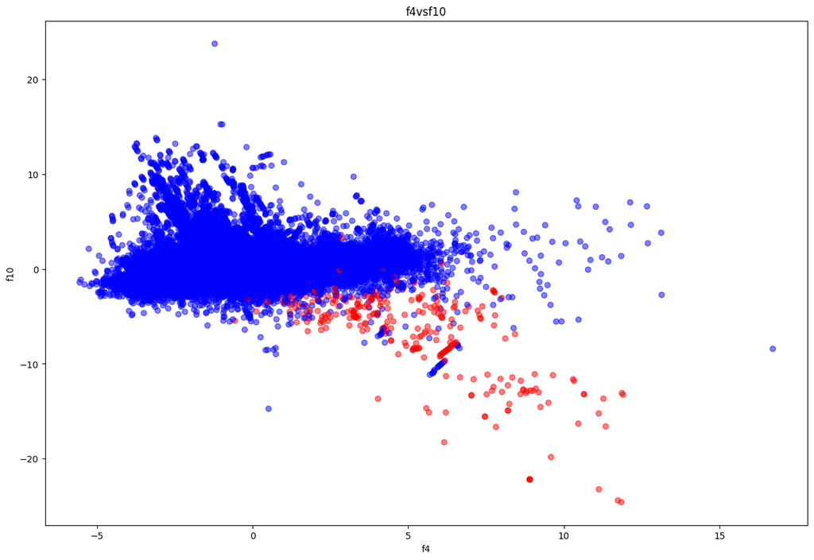

```python
f4 = X_train['V4']
f10 = X_train['V10']
two_feature_plot(f4, f10, 'f4', 'f10')
```

```python
print('Feature V4 and V10')
n_gm_auc(2, f4, f10, 'V4', 'V10')
```

```
Feature V4 and V10
AUC for training sets: 0.9487560542431641
AUC for validation sets: 0.9468776528106408
Best_f1_score: 0.3
Best_threshold: -51.24562602734267
```

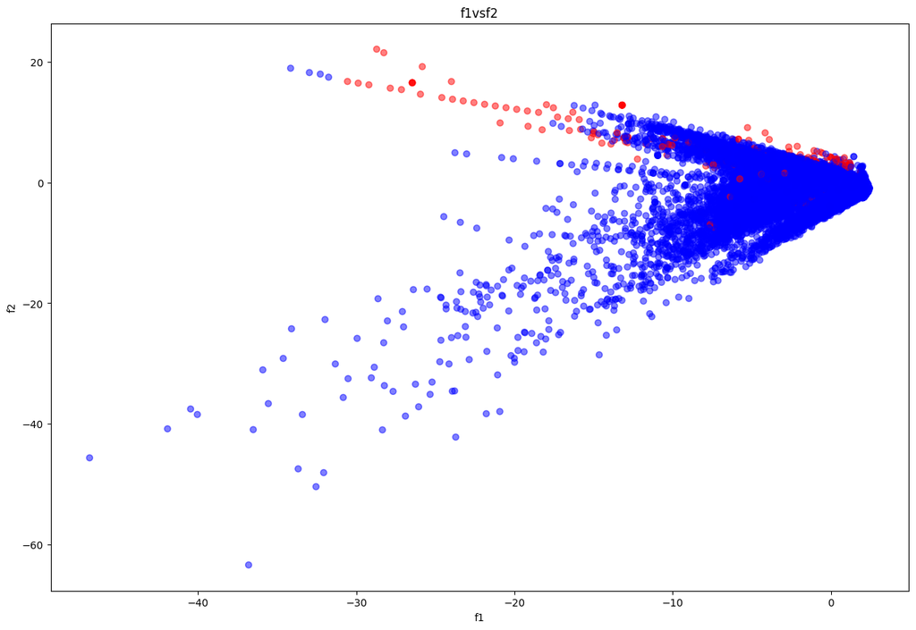

```python
f1 = X_train['V1']
f2 = X_train['V2']
two_feature_plot(f1, f2, 'f1', 'f2')
```

```python
print('Feature V1 and V2')
n_gm_auc(2, f1, f2, 'V1', 'V2')
```

```
Feature V1 and V2
AUC for training sets: 0.8805474329848777
AUC for validation sets: 0.861260934041286
Best_f1_score: 0.08968609865470852
Best_threshold: -23.6379590021553
```

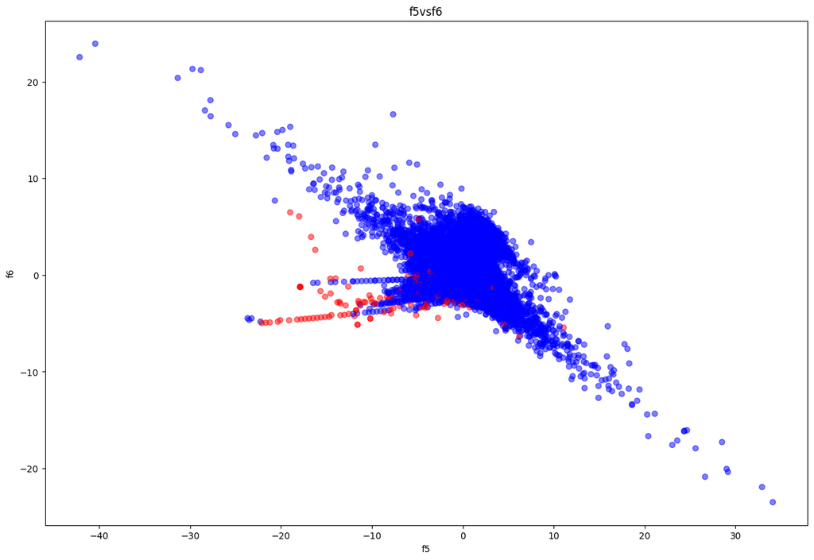

```python
f5 = X_train['V5']
f6 = X_train['V6']
two_feature_plot(f5, f6, 'f5', 'f6')
```

```python
print('Feature V5 and V6')
n_gm_auc(1, f5, f6, 'V5', 'V6')
```

```
Feature V5 and V6
AUC for training sets: 0.8171879008566001
AUC for validation sets: 0.763087782357029
Best_f1_score: 0.11518324607329843
Best_threshold: -22.254664916724778
```

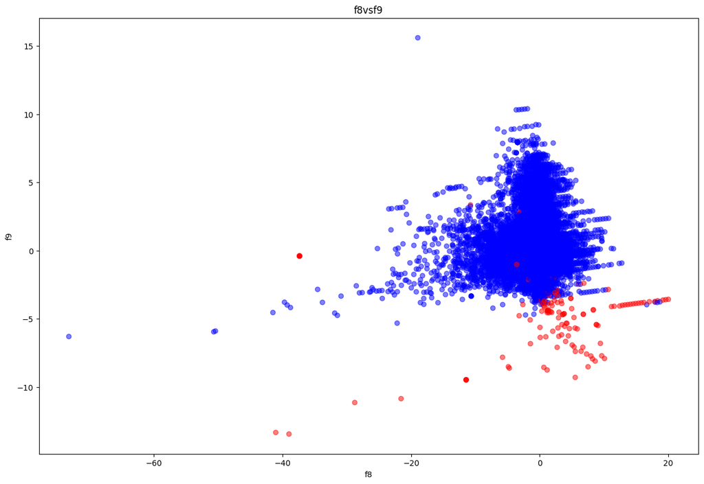

```python
f8 = X_train['V8']
f9 = X_train['V9']
two_feature_plot(f8, f9, 'f8', 'f9')
```

```python
print('Feature V8 and V9')
n_gm_auc(2, f8, f9, 'V8', 'V9')
```

```
Feature V8 and V9
AUC for training sets: 0.8259924203580884
AUC for validation sets: 0.8250766843794811
Best_f1_score: 0.11555555555555555
Best_threshold: -10.160917653919029
```

```python
def estimateGaussian(X):
    """
     This function estimates the parameters of a Gaussian distribution using the data in X
    """

    m = X.shape[0]

    #compute mean of X
    sum_ = np.sum(X,axis=0)
    mu = 1/m *sum_

    # compute variance of X
    var = 1/m * np.sum((X - mu)**2,axis=0)

    return mu,var
```

```python
def multivariateGaussian(X, mu, sigma2):
    """
    Computes the probability density function of the multivariate gaussian distribution.
    """
    k = len(mu)

    sigma2=np.diag(sigma2)
    X = X - mu.T
    #pinv will calculate Moore-Penrose pseudo-inverse of A
    p = 1/((2*np.pi)**(k/2)*(np.linalg.det(sigma2)**0.5))* np.exp(-0.5* np.sum(X @ np.linalg.pinv(sigma2) * X,axis=1))
    return p
```

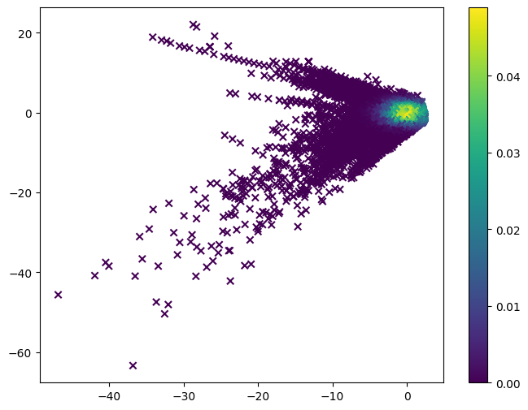

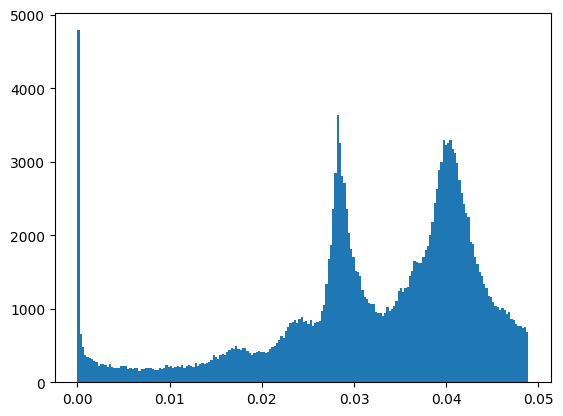

```python
#v1, v2
X = np.array([X_train['V1'], X_train['V2']])
X = np.transpose(X)
mu, sigma2 = estimateGaussian(X)
p = multivariateGaussian(X, mu, sigma2)
sigma2 = np.diag(sigma2)
#print('sigma2:\n', sigma2)
#print('pseudo-inverse of sigma2:\n', np.linalg.pinv(sigma2))
plt.figure(figsize=(8,6))
plt.scatter(X[:,0],X[:,1],marker="x",c=p,cmap='viridis');
plt.colorbar();
plt.show()
_ = plt.hist (p, bins = 200)
plt.show()
```

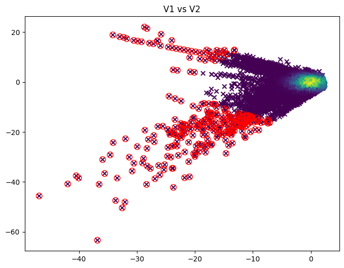

```python
tr = 0.0000000000000000000001
plt.figure(figsize=(8,6))
plt.scatter(X[:,0],X[:,1],marker="x",c=p,cmap='viridis');
# Circling of anomalies
outliers = np.nonzero(p<tr)[0] #indices for which p<tr
plt.scatter(X[outliers,0],X[outliers,1],marker="o",facecolor="none",edgecolor="r",s=70);
plt.title('V1 vs V2')
plt.show()
```

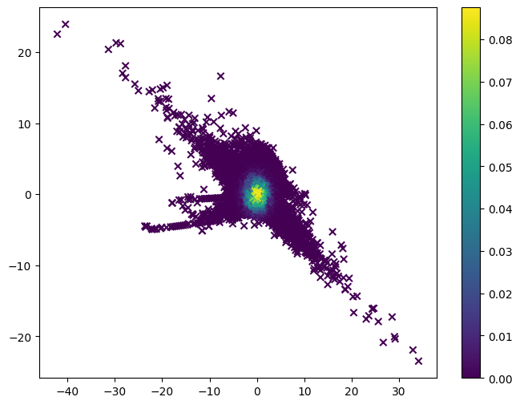

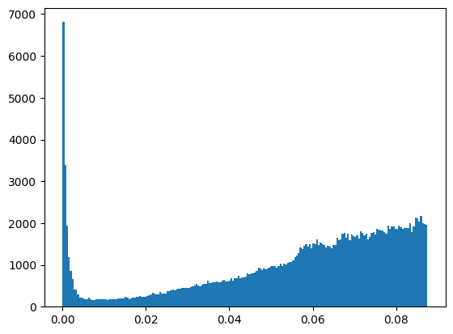

```python
#v5, v6
X = np.array([X_train['V5'], X_train['V6']])
X = np.transpose(X)
mu, sigma2 = estimateGaussian(X)
p = multivariateGaussian(X, mu, sigma2)
sigma2 = np.diag(sigma2)
#print('sigma2:\n', sigma2)
#print('pseudo-inverse of sigma2:\n', np.linalg.pinv(sigma2))
plt.figure(figsize=(8,6))
plt.scatter(X[:,0],X[:,1],marker="x",c=p,cmap='viridis');
plt.colorbar();
plt.show()
_ = plt.hist (p, bins = 200)
plt.show()
```

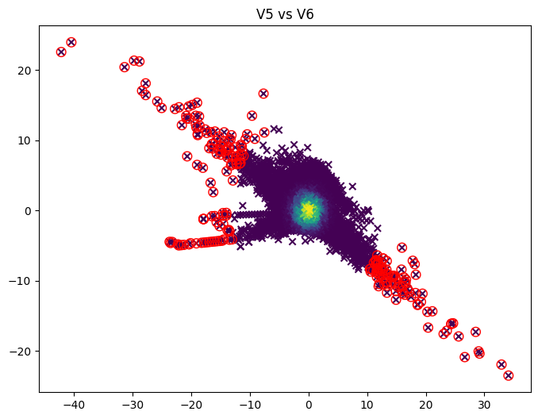

```python
tr = 0.0000000000000000000001
plt.figure(figsize=(8,6))
plt.scatter(X[:,0],X[:,1],marker="x",c=p,cmap='viridis');
# Circling of anomalies
outliers = np.nonzero(p<tr)[0] #indices for which p<tr
plt.scatter(X[outliers,0],X[outliers,1],marker="o",facecolor="none",edgecolor="r",s=70);
plt.title('V5 vs V6')
plt.show()
```

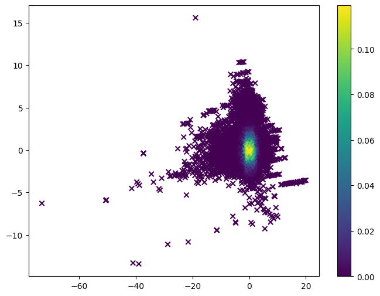

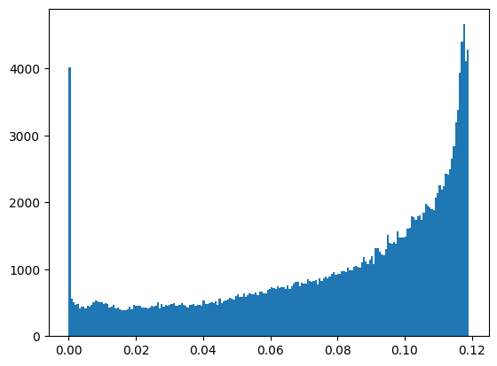

```python
#v8, v9
X = np.array([X_train['V8'], X_train['V9']])
X = np.transpose(X)
mu, sigma2 = estimateGaussian(X)
p = multivariateGaussian(X, mu, sigma2)
sigma2 = np.diag(sigma2)
#print('sigma2:\n', sigma2)
#print('pseudo-inverse of sigma2:\n', np.linalg.pinv(sigma2))
plt.figure(figsize=(8,6))
plt.scatter(X[:,0],X[:,1],marker="x",c=p,cmap='viridis');
plt.colorbar();
plt.show()
_ = plt.hist (p, bins = 200)
plt.show()
```

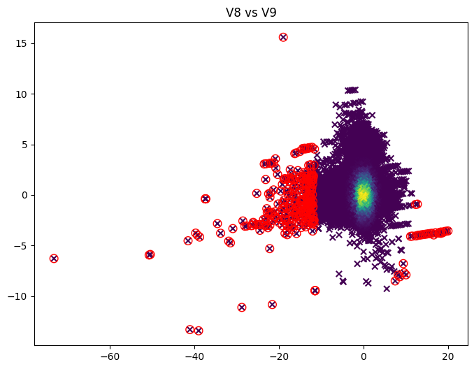

```python
tr = 0.0000000000000000000001
plt.figure(figsize=(8,6))
plt.scatter(X[:,0],X[:,1],marker="x",c=p,cmap='viridis');
# Circling of anomalies
outliers = np.nonzero(p<tr)[0] #indices for which p<tr
plt.scatter(X[outliers,0],X[outliers,1],marker="o",facecolor="none",edgecolor="r",s=70);
plt.title('V8 vs V9')
plt.show()
```

## **Part 4: Single feature model with two Gaussian distributions. [2 Marks]**

Now we will use two different distributions for fraud and not-fraud transactions.

1. Fit a Gaussian distribution ($G_1$) on a feature of **not-fraud transactions** using `sklearn.mixture.GaussianMixture` when `n_components=1`. **[0.25]**
2. Fit another Gaussian distribution ($G_2$) on the same feature but for **fraud transactions** using `sklearn.mixture.GaussianMixture` when `n_components=1`. **[0.25]**
3. Compute the score samples ($S$) for both $G_1$ and $G_2$ on the **validation set** to get $S_1$ and $S_2$, respectively. **[0.25]**
4. Find an optimal $c$ (a real number) that maximizes validation set F1 Score for a model such that if $S_1 < c \times S_2$, the transaction is classified as an anomaly. For example, if $c=1$ we could say that if $S_2$ is greater than $S_1$, ($S_1$<$S_2$) then the transaction is an anomaly (the transaction belongs to the $G_2$ distribution which represents fraud transactions). For start consider $c$ in $[0,10]$ with steps of 0.1, you can change this window in your experiments if needed. **[0.25]**
5. Repeat the steps above for all the features. What is the best F1 Score that you get for training and validation? Which feature and what c? **[1]**

   **best f1 score = 0.655, feature V17, c=7.2**

```python
def best_c(feature):
  g1 = GaussianMixture(n_components=1, random_state=0)
  g1.fit(np.array(X_train[y_train==0][feature]).reshape(-1, 1))
  g2 = GaussianMixture(n_components=1, random_state=0)
  g2.fit(np.array(X_train[y_train==1][feature]).reshape(-1, 1))

  s1 = g1.score_samples(np.array(X_val[feature]).reshape(-1, 1))
  s2 = g2.score_samples(np.array(X_val[feature]).reshape(-1, 1))

  c = np.arange(0, 10.1, 0.1)
  best_f1 = 0
  for val in c:
    pred = (s1<val*s2).astype(int)
    f1 = f1_score(y_val, pred)
    if f1>best_f1:
      best_f1 = f1
      best_c = val
  print('The best f1 score for feature ' + feature + ': ' + str(best_f1))
  print('The best c value for feature ' + feature + ': ' + str(best_c))
  return(best_f1, best_c)
```

```python
for f in features:
  best_c(f)
```

```
The best f1 score for feature V1: 0.0970873786407767
The best c value for feature V1: 5.0
The best f1 score for feature V2: 0.1111111111111111
The best c value for feature V2: 3.7
The best f1 score for feature V3: 0.2736842105263158
The best c value for feature V3: 9.9
The best f1 score for feature V4: 0.36363636363636365
The best c value for feature V4: 4.5
The best f1 score for feature V5: 0.14606741573033707
The best c value for feature V5: 5.0
The best f1 score for feature V6: 0.10687022900763357
The best c value for feature V6: 1.9000000000000001
The best f1 score for feature V7: 0.20779220779220778
The best c value for feature V7: 7.800000000000001
The best f1 score for feature V8: 0.03870967741935484
The best c value for feature V8: 4.9
The best f1 score for feature V9: 0.3655913978494624
The best c value for feature V9: 3.3000000000000003
The best f1 score for feature V10: 0.34090909090909094
The best c value for feature V10: 8.6
The best f1 score for feature V11: 0.5172413793103449
The best c value for feature V11: 3.8000000000000003
The best f1 score for feature V12: 0.611111111111111
The best c value for feature V12: 4.800000000000001
The best f1 score for feature V13: 0.005935976256094975
The best c value for feature V13: 1.1
The best f1 score for feature V14: 0.6371681415929203
The best c value for feature V14: 9.3
The best f1 score for feature V15: 0.0060790273556231
The best c value for feature V15: 1.2000000000000002
The best f1 score for feature V16: 0.5688073394495413
The best c value for feature V16: 4.6000000000000005
The best f1 score for feature V17: 0.6545454545454547
The best c value for feature V17: 7.2
The best f1 score for feature V18: 0.38383838383838387
The best c value for feature V18: 4.4
The best f1 score for feature V19: 0.058252427184466014
The best c value for feature V19: 3.3000000000000003
The best f1 score for feature V20: 0.0101010101010101
The best c value for feature V20: 3.2
The best f1 score for feature V21: 0.03861003861003861
The best c value for feature V21: 1.6
The best f1 score for feature V22: 0.007299270072992701
The best c value for feature V22: 2.2
The best f1 score for feature V23: 0.03015075376884422
The best c value for feature V23: 5.2
The best f1 score for feature V24: 0.005537290188613947
The best c value for feature V24: 1.7000000000000002
The best f1 score for feature V25: 0.017543859649122806
The best c value for feature V25: 1.7000000000000002
The best f1 score for feature V26: 0.003131719173600075
The best c value for feature V26: 0.0
The best f1 score for feature V27: 0.04166666666666667
The best c value for feature V27: 2.7
The best f1 score for feature V28: 0.027465667915106115
The best c value for feature V28: 1.9000000000000001
```

## **Part 5: Multivariate and Mixture of Gaussians Distribution [4 Marks]**

We now want to build an outlier detection model that performs well in terms of F1 score. To design your model, you can benefit from:

- No restrictions on the number of features - use as few or as many as you want! (multivariate).
- To fit your model, you can take advantage of the Gaussian mixture model, where you can set the number of components [help](https://scikit-learn.org/stable/modules/generated/sklearn.mixture.GaussianMixture.html).
- You can choose to fit your Gaussians on not-fraud transactions or to both classes.

It is up to you how to design your model. Try at least 10 different models and report the AUC for both training and validation sets (if applicable) and the best F1 score for both training and validation sets for each model. What kind of model works better? How many features are best (and which ones)? How many Gaussians? How many components? Summarize your findings with tables or plots. **[4]**

**Model with 2 features, 1 Gaussian, and 1 component works better.**

**HINT !**

You might want to try a two-gaussian model, multiple features, a single component for the valid transaction, and multiple components for fraud ones! Why does it make sense to have multiple components for fraud transactions?

Model 1: 1 Gaussian, 1 feature(both classes), 1 component

```python
# Model 1
print('Model 1')
feature_picked = [13] #v14
gm_model_1 = GaussianMixture(n_components = 1, covariance_type = 'full', random_state = 0)
gm_model_1.fit(X_train.iloc[:, feature_picked].values)
train_scores = gm_model_1.score_samples(X_train.iloc[:, feature_picked].values)
val_scores = gm_model_1.score_samples(X_val.iloc[:, feature_picked].values)
auc_train = roc_auc_score(y_train, -train_scores)
auc_val = roc_auc_score(y_val, -val_scores)

print('AUC for training sets: ' + str(auc_train))
print('AUC for validation sets: ' + str(auc_val))

thresholds1 = np.arange(min(train_scores), max(train_scores), 1)
thresholds2 = np.arange(min(val_scores), max(val_scores), 1)
best_f1_score = 0
for threshold in thresholds1:
  predictions = (train_scores < threshold).astype(int)
  f1 = f1_score(y_train, predictions)
  if f1 > best_f1_score:
    best_threshold = threshold
    best_f1_score = f1
print('Best_f1_score for trainning sets: ' + str(best_f1_score))
best_train = best_f1_score
best_f1_score = 0
for threshold in thresholds2:
  predictions = (val_scores < threshold).astype(int)
  f1 = f1_score(y_val, predictions)
  if f1 > best_f1_score:
    best_threshold = threshold
    best_f1_score = f1
print('Best_f1_score for validation sets: ' + str(best_f1_score))
best_val = best_f1_score
gm1 = [auc_train, auc_val, best_train, best_val]
```

```
Model 1
AUC for training sets: 0.9524586211308497
AUC for validation sets: 0.9380726834249067
Best_f1_score for trainning sets: 0.6137404580152672
Best_f1_score for validation sets: 0.5901639344262295
```

Model 2: 1 Gaussian, 2 features(both classes), 1 component

```python
# Model 2
print('Model 2')
feature_picked = [13, 9] #v14, v10
gm_model_2 = GaussianMixture(n_components = 1, covariance_type = 'full', random_state = 0)
gm_model_2.fit(X_train.iloc[:, feature_picked].values)
train_scores = gm_model_2.score_samples(X_train.iloc[:, feature_picked].values)
val_scores = gm_model_2.score_samples(X_val.iloc[:, feature_picked].values)
auc_train = roc_auc_score(y_train, -train_scores)
auc_val = roc_auc_score(y_val, -val_scores)

print('AUC for training sets: ' + str(auc_train))
print('AUC for validation sets: ' + str(auc_val))

thresholds1 = np.arange(min(train_scores), max(train_scores), 1)
thresholds2 = np.arange(min(val_scores), max(val_scores), 1)
best_f1_score = 0
for threshold in thresholds1:
  predictions = (train_scores < threshold).astype(int)
  f1 = f1_score(y_train, predictions)
  if f1 > best_f1_score:
    best_threshold = threshold
    best_f1_score = f1
print('Best_f1_score for trainning sets: ' + str(best_f1_score))
best_train = best_f1_score
best_f1_score = 0
for threshold in thresholds2:
  predictions = (val_scores < threshold).astype(int)
  f1 = f1_score(y_val, predictions)
  if f1 > best_f1_score:
    best_threshold = threshold
    best_f1_score = f1
print('Best_f1_score for validation sets: ' + str(best_f1_score))
best_val = best_f1_score
gm2 = [auc_train, auc_val, best_train, best_val]
```

```
Model 2
AUC for training sets: 0.9538028522657257
AUC for validation sets: 0.9514752164063631
Best_f1_score for trainning sets: 0.4649243466299863
Best_f1_score for validation sets: 0.38571428571428573
```

Model 3: 1 Gaussian, 2 features(both classes), 2 component

```python
# Model 3 (n_component=2)
print('Model 3')
feature_picked = [13, 9] #v14, v10
gm_model_3 = GaussianMixture(n_components = 2, covariance_type = 'full', random_state = 0)
gm_model_3.fit(X_train.iloc[:, feature_picked].values)
train_scores = gm_model_3.score_samples(X_train.iloc[:, feature_picked].values)
val_scores = gm_model_3.score_samples(X_val.iloc[:, feature_picked].values)
auc_train = roc_auc_score(y_train, -train_scores)
auc_val = roc_auc_score(y_val, -val_scores)

print('AUC for training sets: ' + str(auc_train))
print('AUC for validation sets: ' + str(auc_val))

thresholds1 = np.arange(min(train_scores), max(train_scores), 1)
thresholds2 = np.arange(min(val_scores), max(val_scores), 1)
best_f1_score = 0
for threshold in thresholds1:
  predictions = (train_scores < threshold).astype(int)
  f1 = f1_score(y_train, predictions)
  if f1 > best_f1_score:
    best_threshold = threshold
    best_f1_score = f1
print('Best_f1_score for trainning sets: ' + str(best_f1_score))
best_train = best_f1_score
best_f1_score = 0
for threshold in thresholds2:
  predictions = (val_scores < threshold).astype(int)
  f1 = f1_score(y_val, predictions)
  if f1 > best_f1_score:
    best_threshold = threshold
    best_f1_score = f1
print('Best_f1_score for validation sets: ' + str(best_f1_score))
best_val = best_f1_score
gm3 = [auc_train, auc_val, best_train, best_val]
```

```
Model 3
AUC for training sets: 0.9540736297044248
AUC for validation sets: 0.9518195350438692
Best_f1_score for trainning sets: 0.4451313755795981
Best_f1_score for validation sets: 0.3496503496503497
```

Model 4: 1 Gaussian, 3 features(both classes), 1 component

From the result of model 3, it turned out that adding additional component did not help improve the model accuracy. Hence, the parameter for component number is set back to 1. In this model, feature number was increased.

```python
# Model 4
print('Model 4')
feature_picked = [13, 9, 3] #v14, v10, v4
gm_model_4 = GaussianMixture(n_components = 1, covariance_type = 'full', random_state = 0)
gm_model_4.fit(X_train.iloc[:, feature_picked].values)
train_scores = gm_model_4.score_samples(X_train.iloc[:, feature_picked].values)
val_scores = gm_model_4.score_samples(X_val.iloc[:, feature_picked].values)
auc_train = roc_auc_score(y_train, -train_scores)
auc_val = roc_auc_score(y_val, -val_scores)

print('AUC for training sets: ' + str(auc_train))
print('AUC for validation sets: ' + str(auc_val))

thresholds1 = np.arange(min(train_scores), max(train_scores), 1)
thresholds2 = np.arange(min(val_scores), max(val_scores), 1)
best_f1_score = 0
for threshold in thresholds1:
  predictions = (train_scores < threshold).astype(int)
  f1 = f1_score(y_train, predictions)
  if f1 > best_f1_score:
    best_threshold = threshold
    best_f1_score = f1
print('Best_f1_score for trainning sets: ' + str(best_f1_score))
best_train = best_f1_score
best_f1_score = 0
for threshold in thresholds2:
  predictions = (val_scores < threshold).astype(int)
  f1 = f1_score(y_val, predictions)
  if f1 > best_f1_score:
    best_threshold = threshold
    best_f1_score = f1
print('Best_f1_score for validation sets: ' + str(best_f1_score))
best_val = best_f1_score
gm4 = [auc_train, auc_val, best_train, best_val]
```

```
Model 4
AUC for training sets: 0.9632681928045468
AUC for validation sets: 0.9483966438730529
Best_f1_score for trainning sets: 0.481586402266289
Best_f1_score for validation sets: 0.4090909090909091
```

Model 5: 1 Gaussian, 3 features(fraud data only), 1 component

While in previous model the f1 score was higher, this model remains 3 features. However, this time only fraud data are fit in the model.

```python
# Model 5
print('Model 5')
feature_picked = [13, 9, 3] #v14, v10, v4
gm_model_5 = GaussianMixture(n_components = 1, covariance_type = 'full', random_state = 0)
gm_model_5.fit(X_train[y_train==1].iloc[:, feature_picked].values)
train_scores = gm_model_5.score_samples(X_train.iloc[:, feature_picked].values)
val_scores = gm_model_5.score_samples(X_val.iloc[:, feature_picked].values)
auc_train = roc_auc_score(y_train, -train_scores)
auc_val = roc_auc_score(y_val, -val_scores)

print('AUC for training sets: ' + str(auc_train))
print('AUC for validation sets: ' + str(auc_val))

thresholds1 = np.arange(min(train_scores), max(train_scores), 1)
thresholds2 = np.arange(min(val_scores), max(val_scores), 1)
best_f1_score = 0
for threshold in thresholds1:
  predictions = (train_scores < threshold).astype(int)
  f1 = f1_score(y_train, predictions)
  if f1 > best_f1_score:
    best_threshold = threshold
    best_f1_score = f1
print('Best_f1_score for trainning sets: ' + str(best_f1_score))
best_train = best_f1_score
best_f1_score = 0
for threshold in thresholds2:
  predictions = (val_scores < threshold).astype(int)
  f1 = f1_score(y_val, predictions)
  if f1 > best_f1_score:
    best_threshold = threshold
    best_f1_score = f1
print('Best_f1_score for validation sets: ' + str(best_f1_score))
best_val = best_f1_score
gm5 = [auc_train, auc_val, best_train, best_val]
```

```
Model 5
AUC for training sets: 0.21956640801391697
AUC for validation sets: 0.2993308181276764
Best_f1_score for trainning sets: 0.03305785123966942
Best_f1_score for validation sets: 0.02247191011235955
```

For fitting fraud data only, this model tried to analyse the data by 2 components.

```python
# Model 6
print('Model 6')
feature_picked = [13, 9, 3] #v14, v10, v4
gm_model_6 = GaussianMixture(n_components = 2, covariance_type = 'full', random_state = 0)
gm_model_6.fit(X_train[y_train==1].iloc[:, feature_picked].values)
train_scores = gm_model_6.score_samples(X_train.iloc[:, feature_picked].values)
val_scores = gm_model_6.score_samples(X_val.iloc[:, feature_picked].values)
auc_train = roc_auc_score(y_train, -train_scores)
auc_val = roc_auc_score(y_val, -val_scores)

print('AUC for training sets: ' + str(auc_train))
print('AUC for validation sets: ' + str(auc_val))

thresholds1 = np.arange(min(train_scores), max(train_scores), 1)
thresholds2 = np.arange(min(val_scores), max(val_scores), 1)
best_f1_score = 0
for threshold in thresholds1:
  predictions = (train_scores < threshold).astype(int)
  f1 = f1_score(y_train, predictions)
  if f1 > best_f1_score:
    best_threshold = threshold
    best_f1_score = f1
print('Best_f1_score for trainning sets: ' + str(best_f1_score))
best_train = best_f1_score
best_f1_score = 0
for threshold in thresholds2:
  predictions = (val_scores < threshold).astype(int)
  f1 = f1_score(y_val, predictions)
  if f1 > best_f1_score:
    best_threshold = threshold
    best_f1_score = f1
print('Best_f1_score for validation sets: ' + str(best_f1_score))
best_val = best_f1_score
gm6 = [auc_train, auc_val, best_train, best_val]
```

```
Model 6
AUC for training sets: 0.37239172634525974
AUC for validation sets: 0.3855553432723847
Best_f1_score for trainning sets: 0.0030828516377649326
Best_f1_score for validation sets: 0.004983980064079744
```

By contrasting model 5 and model 6, it shows that the f1 score dropped while increasing the component number.

Model 7: 1 Gaussian, 4 features(non-fraud data only), 1 component

```python
# Model 7
print('Model 7')
feature_picked = [13, 9, 3, 15] #v14, v10, v4, v16
gm_model_7 = GaussianMixture(n_components = 1, covariance_type = 'full', random_state = 0)
gm_model_7.fit(X_train[y_train==0].iloc[:, feature_picked].values)
train_scores = gm_model_7.score_samples(X_train.iloc[:, feature_picked].values)
val_scores = gm_model_7.score_samples(X_val.iloc[:, feature_picked].values)
auc_train = roc_auc_score(y_train, -train_scores)
auc_val = roc_auc_score(y_val, -val_scores)

print('AUC for training sets: ' + str(auc_train))
print('AUC for validation sets: ' + str(auc_val))

thresholds1 = np.arange(min(train_scores), max(train_scores), 1)
thresholds2 = np.arange(min(val_scores), max(val_scores), 1)
best_f1_score = 0
for threshold in thresholds1:
  predictions = (train_scores < threshold).astype(int)
  f1 = f1_score(y_train, predictions)
  if f1 > best_f1_score:
    best_threshold = threshold
    best_f1_score = f1
print('Best_f1_score for trainning sets: ' + str(best_f1_score))
best_train = best_f1_score
best_f1_score = 0
for threshold in thresholds2:
  predictions = (val_scores < threshold).astype(int)
  f1 = f1_score(y_val, predictions)
  if f1 > best_f1_score:
    best_threshold = threshold
    best_f1_score = f1
print('Best_f1_score for validation sets: ' + str(best_f1_score))
best_val = best_f1_score
gm7 = [auc_train, auc_val, best_train, best_val]
```

```
Model 7
AUC for training sets: 0.9622039145486874
AUC for validation sets: 0.9530736386991754
Best_f1_score for trainning sets: 0.5932504440497335
Best_f1_score for validation sets: 0.5294117647058824
```

Model 8: 1 Gaussian, 2 features(both classes), 1 component

```python
# Model 8
print('Model 8')
feature_picked = [13, 16] #v14, v17
gm_model_8 = GaussianMixture(n_components = 1, covariance_type = 'full', random_state = 0)
gm_model_8.fit(X_train.iloc[:, feature_picked].values)
train_scores = gm_model_8.score_samples(X_train.iloc[:, feature_picked].values)
val_scores = gm_model_8.score_samples(X_val.iloc[:, feature_picked].values)
auc_train = roc_auc_score(y_train, -train_scores)
auc_val = roc_auc_score(y_val, -val_scores)

print('AUC for training sets: ' + str(auc_train))
print('AUC for validation sets: ' + str(auc_val))

thresholds1 = np.arange(min(train_scores), max(train_scores), 1)
thresholds2 = np.arange(min(val_scores), max(val_scores), 1)
best_f1_score = 0
for threshold in thresholds1:
  predictions = (train_scores < threshold).astype(int)
  f1 = f1_score(y_train, predictions)
  if f1 > best_f1_score:
    best_threshold = threshold
    best_f1_score = f1
print('Best_f1_score for trainning sets: ' + str(best_f1_score))
best_train = best_f1_score
best_f1_score = 0
for threshold in thresholds2:
  predictions = (val_scores < threshold).astype(int)
  f1 = f1_score(y_val, predictions)
  if f1 > best_f1_score:
    best_threshold = threshold
    best_f1_score = f1
print('Best_f1_score for validation sets: ' + str(best_f1_score))
best_val = best_f1_score
gm8 = [auc_train, auc_val, best_train, best_val]
```

```
Model 8
AUC for training sets: 0.9614769283917324
AUC for validation sets: 0.942924286990984
Best_f1_score for trainning sets: 0.6961483594864479
Best_f1_score for validation sets: 0.7111111111111111
```

Model 9: 1 Gaussian, 2 features(non-fraud data only), 1 component

```python
# Model 9
print('Model 9')
feature_picked = [13, 16] #v14, v17
gm_model_9 = GaussianMixture(n_components = 1, covariance_type = 'full', random_state = 0)
gm_model_9.fit(X_train[y_train==0].iloc[:, feature_picked].values)
train_scores = gm_model_9.score_samples(X_train.iloc[:, feature_picked].values)
val_scores = gm_model_9.score_samples(X_val.iloc[:, feature_picked].values)
auc_train = roc_auc_score(y_train, -train_scores)
auc_val = roc_auc_score(y_val, -val_scores)

print('AUC for training sets: ' + str(auc_train))
print('AUC for validation sets: ' + str(auc_val))

thresholds1 = np.arange(min(train_scores), max(train_scores), 1)
thresholds2 = np.arange(min(val_scores), max(val_scores), 1)
best_f1_score = 0
for threshold in thresholds1:
  predictions = (train_scores < threshold).astype(int)
  f1 = f1_score(y_train, predictions)
  if f1 > best_f1_score:
    best_threshold = threshold
    best_f1_score = f1
print('Best_f1_score for trainning sets: ' + str(best_f1_score))
best_train = best_f1_score
best_f1_score = 0
for threshold in thresholds2:
  predictions = (val_scores < threshold).astype(int)
  f1 = f1_score(y_val, predictions)
  if f1 > best_f1_score:
    best_threshold = threshold
    best_f1_score = f1
print('Best_f1_score for validation sets: ' + str(best_f1_score))
best_val = best_f1_score
gm9 = [auc_train, auc_val, best_train, best_val]
```

```
Model 9
AUC for training sets: 0.9608716697429879
AUC for validation sets: 0.9399888306393198
Best_f1_score for trainning sets: 0.7060478199718705
Best_f1_score for validation sets: 0.696969696969697
```

Model 10: 1 Gaussian, 3 features(both classes), 1 component

```python
# Model 10
print('Model 10')
feature_picked = [13, 16, 18] #v14, v17, v19
gm_model_10 = GaussianMixture(n_components = 1, covariance_type = 'full', random_state = 0)
gm_model_10.fit(X_train.iloc[:, feature_picked].values)
train_scores = gm_model_10.score_samples(X_train.iloc[:, feature_picked].values)
val_scores = gm_model_10.score_samples(X_val.iloc[:, feature_picked].values)
auc_train = roc_auc_score(y_train, -train_scores)
auc_val = roc_auc_score(y_val, -val_scores)

print('AUC for training sets: ' + str(auc_train))
print('AUC for validation sets: ' + str(auc_val))

thresholds1 = np.arange(min(train_scores), max(train_scores), 1)
thresholds2 = np.arange(min(val_scores), max(val_scores), 1)
best_f1_score = 0
for threshold in thresholds1:
  predictions = (train_scores < threshold).astype(int)
  f1 = f1_score(y_train, predictions)
  if f1 > best_f1_score:
    best_threshold = threshold
    best_f1_score = f1
print('Best_f1_score for trainning sets: ' + str(best_f1_score))
best_train = best_f1_score
best_f1_score = 0
for threshold in thresholds2:
  predictions = (val_scores < threshold).astype(int)
  f1 = f1_score(y_val, predictions)
  if f1 > best_f1_score:
    best_threshold = threshold
    best_f1_score = f1
print('Best_f1_score for validation sets: ' + str(best_f1_score))
best_val = best_f1_score
gm10 = [auc_train, auc_val, best_train, best_val]
```

```
Model 10
AUC for training sets: 0.9696608822797563
AUC for validation sets: 0.9514650688042416
Best_f1_score for trainning sets: 0.6880222841225627
Best_f1_score for validation sets: 0.6906474820143884
```

```python
df_gm_model = pd.DataFrame({'Model 1':gm1, 'Model 2':gm2, 'Model 3':gm3, 'Model 4':gm4, 'Model 5':gm5, 'Model 6':gm6, 'Model 7':gm7, 'Model 8':gm8, 'Model 9':gm9, 'Model 10':gm10})
df_gm_model.index = ['Train AUC', 'Val AUC', 'Train F1', 'Val F1']
df_gm_model
```

|  | Model 1 | Model 2 | Model 3 | Model 4 | Model 5 | Model 6 | Model 7 | Model 8 | Model 9 | Model 10 |
| --- | --- | --- | --- | --- | --- | --- | --- | --- | --- | --- |
| Train AUC | 0.952459 | 0.953803 | 0.954074 | 0.963268 | 0.219566 | 0.372392 | 0.962204 | 0.961477 | 0.960872 | 0.969661 |
| Val AUC | 0.938073 | 0.951475 | 0.951820 | 0.948397 | 0.299331 | 0.385555 | 0.953074 | 0.942924 | 0.939989 | 0.951465 |
| Train F1 | 0.613740 | 0.464924 | 0.445131 | 0.481586 | 0.033058 | 0.003083 | 0.593250 | 0.696148 | 0.706048 | 0.688022 |
| Val F1 | 0.590164 | 0.385714 | 0.349650 | 0.409091 | 0.022472 | 0.004984 | 0.529412 | 0.711111 | 0.696970 | 0.690647 |

## **Part 6: Evaluating performance on test set: [1 Mark]**

**Which model worked better?** Pick your best model among all models and apply it to your test set. Report the F1 Score, Precision and Recall on the test set. **[1]**

```python
from sklearn.metrics import precision_score, recall_score
# Model 8
print('Model 8 fot test set')
feature_picked = [13, 16] #v14, v17
gm_model_8 = GaussianMixture(n_components = 1, covariance_type = 'full', random_state = 0)
gm_model_8.fit(X_train.iloc[:, feature_picked].values)

test_scores = gm_model_8.score_samples(X_test.iloc[:, feature_picked].values)

auc_test = roc_auc_score(y_test, -test_scores)

print('AUC for test sets: ' + str(auc_test))

thresholds = np.arange(min(test_scores), max(test_scores), 0.5)
best_f1_score = 0
for threshold in thresholds:
  predictions = (test_scores < threshold).astype(int)
  f1 = f1_score(y_test, predictions)
  if f1 > best_f1_score:
    f1_threshold = threshold
    best_f1_score = f1
predictions = (test_scores < f1_threshold).astype(int)
precision = precision_score(y_test, predictions)
recall = recall_score(y_test, predictions)
print('F1: ' + str(best_f1_score))
print('Precision: :' + str(precision))
print('Recall: ' + str(recall))
```

```
Model 8 fot test set
AUC for test sets: 0.9748478612635431
F1: 0.7066666666666666
Precision: :0.7571428571428571
Recall: 0.6625
```

## **Part 7: Is Gaussian the only useful distribution? [1 Mark]**

Search for other distributions that could be used to model the data. How popular are they? Is there a specific situation where a distribution works better? How can we find a suitable distribution to model our data? Do not forget to include your references.

**1.Bernoulli Distribution**

- The Bernoulli distribution is a discrete probability distribution that models a random experiment with two possible outcomes: success and failure.
- The Bernoulli distribution is well-suited for modeling when the outcome of each trial can be categorized into one of two distinct categories, each trial is independent of the others, and the probability of one of the two outcomes remains constant across all trials.

**2.Uniform Distribution**

- The uniform distribution is a simple and fundamental probability distribution that describes a random variable with a constant probability of taking any value within a specified range.
- The uniform distribution is well-suited for modeling when each value within a specified range has an equal probability of occurring.

**3.Binomial Distribution**

- The binomial distribution is a discrete probability distribution that models the number of successful outcomes in a fixed number of independent Bernoulli trials. It is characterized by two parameters: the number of trials and the probability of success.
- The binomial distribution is well-suited for modeling when you have a fixed number of independent trials, and each trial has two possible outcomes.

**4.Poisson Distribution**

- The Poisson distribution is a discrete probability distribution that models the number of events occurring in a fixed interval of time or space, given a known average rate of occurrence.
- The Poisson distribution is well-suited for modeling when you are interested in counting the number of events or occurrences within a fixed interval of time or space when the events are rare and random, and the average rate of occurrence is known.

**5.Exponential Distribution**

- The exponential distribution is a continuous probability distribution that models the time between events in a Poisson process, where events occur at a constant average rate.
- The exponential distribution is well-suited for modeling when the waiting times between successive events or arrivals exhibit exponential decay, events occur at a constant average rate, and the probability of an event occurring in the next time interval is not influenced by how much time has already passed.

**How can we find a suitable distribution to model our data?**

Understand the data, visualize the data , and choose candidate probability distributions that you believe might be suitable.

References:

https://www.analyticsvidhya.com/blog/2017/09/6-probability-distributions-data-science/